# CHIS ASSP Weather Covariate Data

Amelia DuVall

29 June 2020

This is v.2020-09-11

This notebook documents pulling `ERA5` data for weather covariates for the Ashy Storm-Petrel catch-per-unit-effort analysis at Channel Islands National Park.

### Load your data

```r
# install any missing packages
# install.packages(c("raster","ncdf4","oce","dplyr", "lubridate","tidyr","purrr","here","reticulate"))

# A key package for this workflow is `velox` (for fast raster extraction).  It is
# no longer maintained and may not work with new versions of R.  We can discus
# ideas for working around it if you have issues, but for now, installing from
# github is the best option

# devtools::install_github("hunzikp/velox")

library(easypackages)
libraries("raster","ncdf4","velox","oce","dplyr","lubridate","tidyr","purrr","here","reticulate")
## I used miniconda to get python to work.
# install.packages("remotes")
# remotes::install_github("hafen/rminiconda")

# set the local time zone
project_tz = "America/Los_Angeles"

# load the data
dat_raw<-readRDS(here::here("ASSP_share", "ASSP_4_wx.RDS"))

#look at the data
head(dat_raw)
```

|  | session_ID | island_code | site_code | lat | long | session_year | session_date | start | end |
| --- | --- | --- | --- | --- | --- | --- | --- | --- | --- |
| 1 | 1994-06-16_SBI_AP | SBI | AP | 33.48762 | -119.0285 | 1994 | 1994-06-16 | 1994-06-17 01:36:00 | 1994-06-17 02:40:00 |
| 2 | 1994-07-03_SBI_AP | SBI | AP | 33.48762 | -119.0285 | 1994 | 1994-07-03 | 1994-07-04 00:30:00 | 1994-07-04 03:30:00 |
| 3 | 1994-07-13_SBI_AP | SBI | AP | 33.48762 | -119.0285 | 1994 | 1994-07-13 | 1994-07-14 00:00:00 | 1994-07-14 03:00:00 |
| 4 | 1994-07-12_SBI_ESP | SBI | ESP | 33.48253 | -119.0416 | 1994 | 1994-07-12 | 1994-07-12 23:35:00 | 1994-07-13 02:35:00 |
| 5 | 1994-08-12_SBI_ESP | SBI | ESP | 33.48253 | -119.0416 | 1994 | 1994-08-12 | 1994-08-12 22:50:00 | 1994-08-13 02:00:00 |
| 6 | 1995-05-14_SBI_ESP | SBI | ESP | 33.48253 | -119.0416 | 1995 | 1995-05-14 | 1995-05-14 23:00:00 | 1995-05-15 02:00:00 |

```r
# create a DF with one row per hour of effort
dat<-dat_raw %>%
  rowwise %>%
  mutate(DateTime_h=seq(from = floor_date(start,unit = "hour"),
                        to = ceiling_date(end,"hour"),
                        by = "1 hour") %>%
           unique %>%
           list) %>%
  unnest(cols = c(DateTime_h)) %>%
  mutate(Longitude360=ifelse(long<0,long+360,long),
         Latitude=lat)

## do not need to fix time zones
  # mutate(DateTime_h = DateTime_h %>% #fix the time zones
  #          force_tz(project_tz) %>%
  #          with_tz("UTC"),
  #        Longitude360=ifelse(long<0,long+360,long),
  #        Latitude=lat)

head(dat) %>% as.data.frame()
```

| session_ID | island_code | site_code | lat | long | session_year | session_date | start | end | DateTime_h | Longitude360 | Latitude |
| --- | --- | --- | --- | --- | --- | --- | --- | --- | --- | --- | --- |
| 1994-06-16_SBI_AP | SBI | AP | 33.48762 | -119.0285 | 1994 | 1994-06-16 | 1994-06-17 01:36:00 | 1994-06-17 02:40:00 | 1994-06-17 01:00:00 | 240.9715 | 33.48762 |
| 1994-06-16_SBI_AP | SBI | AP | 33.48762 | -119.0285 | 1994 | 1994-06-16 | 1994-06-17 01:36:00 | 1994-06-17 02:40:00 | 1994-06-17 02:00:00 | 240.9715 | 33.48762 |
| 1994-06-16_SBI_AP | SBI | AP | 33.48762 | -119.0285 | 1994 | 1994-06-16 | 1994-06-17 01:36:00 | 1994-06-17 02:40:00 | 1994-06-17 03:00:00 | 240.9715 | 33.48762 |
| 1994-07-03_SBI_AP | SBI | AP | 33.48762 | -119.0285 | 1994 | 1994-07-03 | 1994-07-04 00:30:00 | 1994-07-04 03:30:00 | 1994-07-04 00:00:00 | 240.9715 | 33.48762 |
| 1994-07-03_SBI_AP | SBI | AP | 33.48762 | -119.0285 | 1994 | 1994-07-03 | 1994-07-04 00:30:00 | 1994-07-04 03:30:00 | 1994-07-04 01:00:00 | 240.9715 | 33.48762 |
| 1994-07-03_SBI_AP | SBI | AP | 33.48762 | -119.0285 | 1994 | 1994-07-03 | 1994-07-04 00:30:00 | 1994-07-04 03:30:00 | 1994-07-04 02:00:00 | 240.9715 | 33.48762 |

### Download data from Climate Data Store

To access the Climate Data Store, you must first register for an account, follow the directions for setting up your computer to access the api (“install” the key), and download the API client (a python package). Please go to [this page](https://cds.climate.copernicus.eu/api-how-to) for instructions.

Once things are set up, we can run `python` in `RStudio` (version 1.2+) using the `reticulate` package. To do so, must point `RStudio` to the `python` executable with the `use_python()` function.

```r
# use_python(python = "C:/Users/ConservationMetrics/AppData/Local/r-miniconda/python.exe")
# use_python(python = "C:/Users/Amelia DuVall/AppData/Local/Programs/Python/Python38-32/python.exe")

## I opted to use rminiconda instead.
rminiconda::install_miniconda(version = 3, name = "my_python")
py <- rminiconda::find_miniconda_python("my_python")
reticulate::use_python(py, required = TRUE)
```

```r
# these will give you the values needed for downloading via python
floor(min(dat$lat))
ceiling(max(dat$lat))
floor(min(dat$long)+360)
ceiling(max(dat$long)+360)

dates_to_download<-dat %>%
  group_by(year=year(DateTime_h),
           month=month(DateTime_h),
           day=day(DateTime_h),add=T) %>%
  count %>%
  as.data.frame()

dates_to_download
```

[output not shown]

```python
# load the climate data store API library
import cdsapi

# Define the years and months you want the data for
# years = ['1994', '1995', '2004', '2005', '2006', '2007', '2009', '2011', '2014', '2015', '2016', '2017', '2018']
years = ['1995', '2007','2017', '2018']
months = [4, 5, 6, 7, 8, 9]

# define the bounding box for the area you are interested in downloading.
lats = [32, 35]
lons = [238, 242]

# Start the client (and call it 'c')
c = cdsapi.Client()

for jj in years:
        c.retrieve(
            'reanalysis-era5-single-levels',
            {
                'product_type':'reanalysis',
                'format':'netcdf', # Supported format: grib and netcdf. Default: grib
                'grid': [0.25, 0.25],# Latitude/longitude grid: east-west (longitude) and north-south resolution (latitude). Default: 0.25 x 0.25
                'area': [lats[0], lons[0], lats[1], lons[1]],# North, West, South, East. Default: global
                'variable':[
      '10m_u_component_of_wind','10m_v_component_of_wind','2m_dewpoint_temperature',
      '2m_temperature','low_cloud_cover','mean_sea_level_pressure',
      'mean_wave_direction','mean_wave_period','sea_surface_temperature',
      'significant_height_of_combined_wind_waves_and_swell','surface_pressure','total_cloud_cover',
      'total_precipitation'
      ],
                'year':jj,
                'month':months,
                'day':[
                    '01','02','03',
                    '04','05','06',
                    '07','08','09',
                    '10','11','12',
                    '13','14','15',
                    '16','17','18',
                    '19','20','21',
                    '22','23','24',
                    '25','26','27',
                    '28','29','30',
                    '31'
                ],
                'time':[
                    '00:00','01:00','02:00',
                    '03:00','04:00','05:00',
                    '06:00','07:00','08:00',
                    '09:00','10:00','11:00',
                    '12:00','13:00','14:00',
                    '15:00','16:00','17:00',
                    '18:00','19:00','20:00',
                    '21:00','22:00','23:00'
                ]
            },
            'C:/Users/Amelia DuVall/wx/era5_'+jj+'_N'+'{:02d}'.format(lats[1])+'_W'+'{:03d}'.format(lons[0])+'_S'+'{:02d}'.format(lats[0])+'_E'+'{:03d}'.format(lons[1])+'.nc')
```

### Extracting and attaching WX to your Data

Now that you have downloaded the weather data as rasters lets look at a few.

### Load weather data

Issue with velox?

```r
# ERA5 functions

#' Read NC names
read_nc_names<-function(nc){
  data.frame(name=names(nc$var),
             longname=purrr::map_chr(names(nc$var),
                                     function(x)nc$var[[x]]$longname))
}

#' Read ERA5 Raster Stack
read_stack<-function(file_list,varname){
  temp<-lapply(file_list, function(x)stack(x,varname=varname))
  stack(temp)
}

#' Read a date and extract with velox
read_vx_date<-function(dat,spdf,datex){
  vx<- velox(dat[[datex]])
  vx$extract(spdf, fun=function(x)mean(x,na.rm=T))
}

# List your files (can be a single file)
files<-list.files(here::here("ASSP_share", 'ERA5'),pattern = "\\.nc$",full.names = T,recursive = T)
files<-as.character(files)

# open a connection to one of the files
nc<-files[1] %>% ncdf4::nc_open()

# you can see  info about this file by printing it, but there is too much info
# to see what we are looking for.
nc
```

```
File C:/Users/ekelsey/Documents/WERC-SC/ASSP_share/ERA5/era5_1994_N35_W238_S32_E242.nc (NC_FORMAT_64BIT):

     13 variables (excluding dimension variables):
        short u10[longitude,latitude,time]
            scale_factor: 0.000345144853517264
            add_offset: 3.5520887801123
            _FillValue: -32767
            missing_value: -32767
            units: m s**-1
            long_name: 10 metre U wind component
        short v10[longitude,latitude,time]
            scale_factor: 0.000340083116446938
            add_offset: -1.90755682134338
            _FillValue: -32767
            missing_value: -32767
            units: m s**-1
            long_name: 10 metre V wind component
        short d2m[longitude,latitude,time]
            scale_factor: 0.000729435918139525
            add_offset: 272.486024442197
            _FillValue: -32767
            missing_value: -32767
            units: K
            long_name: 2 metre dewpoint temperature
        short t2m[longitude,latitude,time]
            scale_factor: 0.000639724958465582
            add_offset: 294.055222129708
            _FillValue: -32767
            missing_value: -32767
            units: K
            long_name: 2 metre temperature
        short lcc[longitude,latitude,time]
            scale_factor: 1.52594875864068e-05
            add_offset: 0.499992370256207
            _FillValue: -32767
            missing_value: -32767
            units: (0 - 1)
            long_name: Low cloud cover
        short msl[longitude,latitude,time]
            scale_factor: 0.0305561701738056
```

[output cut: 58 more lines]

```
     3 dimensions:
        longitude  Size:17
            units: degrees_east
            long_name: longitude
        latitude  Size:13
            units: degrees_north
            long_name: latitude
        time  Size:4392
            units: hours since 1900-01-01 00:00:00.0
            long_name: time
            calendar: gregorian

    2 global attributes:
        Conventions: CF-1.6
        history: 2020-08-28 19:42:28 GMT by grib_to_netcdf-2.16.0: /opt/ecmwf/eccodes/bin/grib_to_netcdf -S param -o /cache/data4/adaptor.mars.internal-1598640542.4342277-18333-7-e9eb6ed8-eb2b-4c76-a85f-1ab18aae00a2.nc /cache/tmp/e9eb6ed8-eb2b-4c76-a85f-1ab18aae00a2-adaptor.mars.internal-1598640542.…
```

```r
# So use the helper function from the ERA5 package I am writing
names<-read_nc_names(nc)

# Now that we know the names we can load the files with the read_stack function
# from the ERA5 package I am writing
u10<-read_stack(files,varname = "u10")
u10
```

```
class      : RasterStack
dimensions : 13, 17, 221, 57096  (nrow, ncol, ncell, nlayers)
resolution : 0.25, 0.25  (x, y)
extent     : 237.875, 242.125, 31.875, 35.125  (xmin, xmax, ymin, ymax)
crs        : +proj=longlat +datum=WGS84 +ellps=WGS84 +towgs84=0,0,0
names      : X1994.04.01.00.00.00, X1994.04.01.01.00.00, X1994.04.01.02.00.00, X1994.04.01.03.00.00, X1994.04.01.04.00.00, X1994.04.01.05.00.00, X1994.04.01.06.00.00, X1994.04.01.07.00.00, X1994.04.01.08.00.00, X1994.04.01.09.00.00, X1994.04.01.10.00.00, X1994.04.01.11.00.00, X1994.04.01.12.00.00, X…
```

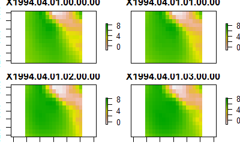

```r
plot(u10[[1:4]])
```

```r
# Go ahead and load all the vars
v10<-read_stack(files,varname = "v10")
swh<-read_stack(files,varname = "swh")
mwd<-read_stack(files,varname = "mwd")
tp<- read_stack(files,varname = "tp")
tcc<-read_stack(files,varname = "tcc")
sp<- read_stack(files,varname = "sp")
sst<-read_stack(files,varname = "sst")
mwp<-read_stack(files,varname = "mwp")
msl<-read_stack(files,varname = "msl")
lcc<-read_stack(files,varname = "lcc")
t2m<-read_stack(files,varname = "t2m")
d2m<-read_stack(files,varname = "d2m")
```

### Create a “Dates” table

We are going to loop through the data and with each loop we will attach the data to our data.frame of interest, but first we must create a table of dates to loop through. First we will extract the “dates” from the names of the layers in the raster stacks.

```r
# Create a date table for the ERA5 vars
DateTable<-data.frame(xdate=names(tp),
                      DateTime=ymd_hms(gsub("X","",names(tp)),tz="UTC") %>%
                        with_tz(project_tz)
) %>%
  mutate(
    year=year(DateTime),
    month=month(DateTime),
    day=day(DateTime),
    hour=hour(DateTime),
    minute=minute(DateTime),
    second=second(DateTime),
    Date=as.Date(DateTime)
  )
```

### Loop through Dates and attach

Now the moment we have all been waiting for!!! We are going to loop through each raster layer and extract the mean value within 20km or 40km of each point (for atmospheric and oceanic vars respectively).

[output not shown]

[output cut: 912 more lines]

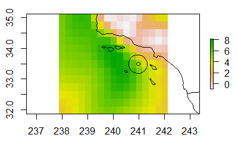

```r
# Get the unique Dates in the dat data frame for which we will loop through
Dates<-sort(unique(dat$DateTime_h))

# go through each Date in the dat data, extract the vars at each of the
# points with a buffer, aggregate the buffered data to end up with a single
# value for each point.

buff <- 20000

# Create empty columns to populate
dat$tot_precip<-NA
dat$wind_u<-NA
dat$wind_v<-NA
dat$wave_height<-NA
dat$wave_dir<-NA
dat$wave_period<-NA
dat$tot_cloud<-NA
dat$low_cloud<-NA
dat$pressure<-NA
dat$surface_pressure<-NA
dat$sst<-NA
dat$temp_c<-NA
dat$dew_point<-NA

for(i in 1:length(Dates)){

  print(paste("i =",i,"; Date/Time =",Dates[i]))

  # This is the index for a single date/time
  datex<-as.character(DateTable$xdate[DateTable$DateTime==Dates[i]])[1]

  # If the datetime isNA skip
  if(length(datex)<1|is.na(datex)) next

  # subset the specific rows in your data that corrispond to datex
  dat_subseter<-which(dat$DateTime_h==Dates[i])

  # Create a SpatialPointsDataFrame for the atmospheric variables
  pt<-data.frame(Longitude360=dat$Longitude360[dat_subseter],
                 Latitude=dat$Latitude[dat_subseter])

  coordinates(pt)<-cbind(dat$Longitude360[dat_subseter],
                         dat$Latitude[dat_subseter])
  crs(pt)<-CRS("+proj=longlat +ellps=WGS84 +datum=WGS84 +lon_wrap=180")

  # reproject into an equalarea projection
  pt_sp<-spTransform(pt,CRS("+proj=utm +zone=4 +north"))
  # buffer by buff (at least 20km?)
  spol <- rgeos::gBuffer(pt_sp, width=buff, byid=TRUE)

  #reproejct in to latlong again
  spdf <- SpatialPolygonsDataFrame(spol, data.frame(id=1:length(spol)), FALSE)
  spdf <- spTransform(spdf,CRS("+proj=longlat +ellps=WGS84 +datum=WGS84 +lon_wrap=180"))

  # repeat for the Oceanic vars (bigger buffer)
  spol1 <- rgeos::gBuffer(pt_sp, width=buff*2, byid=TRUE)

  spdf1 <- SpatialPolygonsDataFrame(spol1, data.frame(id=1:length(spol1)), FALSE)
  spdf1 <- spTransform(spdf1,CRS("+proj=longlat +ellps=WGS84 +datum=WGS84 +lon_wrap=180"))

  if(i==1){
    plot(u10[[datex]])
    points(pt)
    plot(spdf1,add=T)
    maps::map('world2',add = T)
  }
  dat$tot_precip[dat_subseter] <- read_vx_date(dat=tp,spdf = spdf,datex=datex)

  dat$wind_u[dat_subseter] <- read_vx_date(dat=u10,spdf = spdf,datex=datex)

  dat$wind_v[dat_subseter] <- read_vx_date(dat=v10,spdf = spdf,datex=datex)

  dat$wave_height[dat_subseter] <- read_vx_date(dat=swh,spdf = spdf1,datex=datex)

  dat$wave_dir[dat_subseter] <- read_vx_date(dat=mwd,spdf = spdf1,datex=datex)

  dat$wave_period[dat_subseter] <- read_vx_date(dat=mwp,spdf = spdf1,datex=datex)

  dat$tot_cloud[dat_subseter] <- read_vx_date(dat=tcc,spdf = spdf,datex=datex)

  dat$low_cloud[dat_subseter] <- read_vx_date(dat=lcc,spdf = spdf,datex=datex)

  dat$pressure[dat_subseter] <- read_vx_date(dat=msl,spdf = spdf,datex=datex)

  dat$surface_pressure[dat_subseter] <- read_vx_date(dat=sp,spdf = spdf,datex=datex)

  dat$sst[dat_subseter] <- read_vx_date(dat=sst,spdf = spdf1,datex=datex)

  dat$temp_c[dat_subseter] <- read_vx_date(dat=t2m,spdf = spdf,datex=datex)

  dat$dew_point[dat_subseter] <- read_vx_date(dat=d2m,spdf = spdf,datex=datex)

}
```

### add Moon variables

The last thing we will do is add some moon variables. We will use the oce package

```r
# Moon data -------------------------------------------------------------------

# generate moon data and use moon altitude to determine if the moon was above
# the horizon

# The time needs to be in UTC
tz(dat$DateTime_h)

moonInfo<-oce::moonAngle(dat$DateTime_h,
                    longitude =dat$long,
                    latitude = dat$lat)

moonInfo<-bind_rows(moonInfo)

# T or F for if moon is above horizon
dat$Moonup<-ifelse(moonInfo$altitude>0,1,0)
dat$MoonAltitude<-moonInfo$altitude
dat$Illu<-moonInfo$illuminatedFraction
```

# Save

And there you have it, this concludes the instructions on how to use the era5 data attacher!

```r
# summarize the mean per session (group by all the vars you want in the final dataset)
dat_out<-dat %>% group_by(session_ID,
                          island_code,
                          site_code,
                          lat,
                          long,
                          start,
                          end) %>%
  mutate(tot_precip=ifelse(tot_precip<0,0,tot_precip),
         wave_height=ifelse(wave_height<0,NA,wave_height),
         wave_period=ifelse(wave_period<0,NA,wave_period),
         tot_cloud=ifelse(tot_cloud<0,NA,tot_cloud),
         low_cloud=ifelse(low_cloud<0,NA,low_cloud),
         pressure=ifelse(pressure<0,NA,pressure),
         surface_pressure=ifelse(surface_pressure<0,NA,surface_pressure),
         sst=ifelse(sst<0,NA,sst),
         temp_c=ifelse(temp_c<0,NA,temp_c),
         dew_point=ifelse(dew_point<0,NA,dew_point)) %>%
  summarise(tot_precip = mean(tot_precip ,na.rm=T),
            wind_u = mean(wind_u ,na.rm=T),
            wind_v = mean(wind_v ,na.rm=T),
            wave_height = mean(wave_height ,na.rm=T),
            wave_dir = mean(wave_dir ,na.rm=T),
            wave_period = mean(wave_period ,na.rm=T),
            tot_cloud = mean(tot_cloud ,na.rm=T),
            low_cloud = mean(low_cloud ,na.rm=T),
            pressure = mean(pressure/100 ,na.rm=T),
            surface_pressure = mean(surface_pressure/100 ,na.rm=T),
            sst = mean(sst-273 ,na.rm=T),
            temp_c = mean(temp_c ,na.rm=T),
            dew_point = mean(dew_point-273 ,na.rm=T),
            Moonup = mean(Illu ,na.rm=T),
            MoonAltitude = mean(MoonAltitude ,na.rm=T),
            Illu = mean(Illu ,na.rm=T))

par(mfrow=c(3,6))
hist(dat_out$tot_precip,breaks=30)
hist(dat_out$wind_u,breaks=30)
hist(dat_out$wind_v,breaks=30)
hist(dat_out$wave_height,breaks=30)
hist(dat_out$wave_dir,breaks=30)
hist(dat_out$wave_period,breaks=30)
hist(dat_out$pressure,breaks=30)
hist(dat_out$tot_cloud,breaks=30)
hist(dat_out$low_cloud,breaks=30)
hist(dat_out$surface_pressure,breaks=30)
hist(dat_out$sst,breaks=30)
hist(dat_out$dew_point,breaks=30)
hist(dat_out$temp_c,breaks=30)
hist(dat_out$Illu,breaks=30)
hist(dat_out$MoonAltitude,breaks=30)
hist(dat_out$Moonup,breaks=30)

# saveRDS(dat_out,here::here("Data","mistnet_w_weather.rds"))
# write.csv(dat_out,here::here("Data","mistnet_w_weather.csv"),row.names=F)
```

[output not shown]